# Lab Assignment Four: Multi-Layer Perceptron

## Course: Maching Learning in Python

## Semester: Fall 2023

### Team: Perceptron

### Authors

Brian Mendes (49243148)

Prashant Iyer (49352530)

Ritik K (49347408)

### Data Sources:

US Census Data Kaggle - https://www.kaggle.com/muonneutrino/us-census-demographic-data/data

```python
import pandas as pd
import matplotlib.pyplot as plt
%matplotlib inline
from sklearn.model_selection import train_test_split
from sklearn.metrics import mean_squared_error
from sklearn.preprocessing import StandardScaler
```

```python
#Read Dataset
df = pd.read_csv('acs2017_census_tract_data.csv')
```

```python
#Storing a copy for future reference
data = df.copy()
```

```python
df.columns
```

```
Index(['TractId', 'State', 'County', 'TotalPop', 'Men', 'Women', 'Hispanic',
       'White', 'Black', 'Native', 'Asian', 'Pacific', 'VotingAgeCitizen',
       'Income', 'IncomeErr', 'IncomePerCap', 'IncomePerCapErr', 'Poverty',
       'ChildPoverty', 'Professional', 'Service', 'Office', 'Construction',
       'Production', 'Drive', 'Carpool', 'Transit', 'Walk', 'OtherTransp',
       'WorkAtHome', 'MeanCommute', 'Employed', 'PrivateWork', 'PublicWork',
       'SelfEmployed', 'FamilyWork', 'Unemployment'],
      dtype='object')
```

```python
df.dtypes
```

```
TractId               int64
State                object
County               object
TotalPop              int64
Men                   int64
Women                 int64
Hispanic            float64
White               float64
Black               float64
Native              float64
Asian               float64
Pacific             float64
VotingAgeCitizen      int64
Income              float64
IncomeErr           float64
IncomePerCap        float64
IncomePerCapErr     float64
Poverty             float64
ChildPoverty        float64
Professional        float64
Service             float64
Office              float64
Construction        float64
Production          float64
Drive               float64
Carpool             float64
Transit             float64
Walk                float64
OtherTransp         float64
WorkAtHome          float64
MeanCommute         float64
Employed              int64
PrivateWork         float64
PublicWork          float64
SelfEmployed        float64
FamilyWork          float64
Unemployment        float64
dtype: object
```

```python
# Encoding Categorical data
from sklearn.preprocessing import LabelEncoder

label_encoder = LabelEncoder()
df['State'] = label_encoder.fit_transform(df['State'])
df['County'] = label_encoder.fit_transform(df['County'])
```

We would be including the County variable as it helps add contextual information about the ChildPoverty in that region. Every county might have some features corresponding specific to the region. Including this feature might help conver this base as well

```python
#Dropping Null column
df.dropna(inplace=True)
df.drop('TractId',axis=1,inplace=True)
```

```python
#Data Types of every
df.dtypes
```

```
State                 int64
County                int64
TotalPop              int64
Men                   int64
Women                 int64
Hispanic            float64
White               float64
Black               float64
Native              float64
Asian               float64
Pacific             float64
VotingAgeCitizen      int64
Income              float64
IncomeErr           float64
IncomePerCap        float64
IncomePerCapErr     float64
Poverty             float64
ChildPoverty        float64
Professional        float64
Service             float64
Office              float64
Construction        float64
Production          float64
Drive               float64
Carpool             float64
Transit             float64
Walk                float64
OtherTransp         float64
WorkAtHome          float64
MeanCommute         float64
Employed              int64
PrivateWork         float64
PublicWork          float64
SelfEmployed        float64
FamilyWork          float64
Unemployment        float64
dtype: object
```

```python
X, y = df.drop("ChildPoverty",axis=1).values , df["ChildPoverty"].values
```

```python
from sklearn.model_selection import train_test_split
X_train, X_test, y_train, y_test = train_test_split(X, y, test_size=0.2)
```

```python
print(X_train.shape)
print(X_test.shape)
print(y_train.shape)
print(y_test.shape)
```

```
(58174, 35)
(14544, 35)
(58174,)
(14544,)
```

```python
# Spliting data into 4 classes
import math
def quantize_poverty(y_train, y_test):
    threshold_points = []
    i = 0

    # Find threshold points
    while True:
        if int((y_train < i).sum()) >= math.floor(len(y_train) / 4):
            threshold_points.append(i)
            while True:
                if int((y_train < i).sum()) >= math.floor(len(y_train) / 2):
                    threshold_points.append(i)
                    while True:
                        if int((y_train < i).sum()) >= math.floor(len(y_train) * 3 / 4):
                            threshold_points.append(i)
                            break
                        else:
                            i += 0.001
                    break
                else:
                    i += 0.001
            break
        else:
            i += 0.001

    print("Threshold Points:", threshold_points)

    # Quantize y_train
    y_train_copy = y_train.copy()
    y_train_copy[y_train_copy < threshold_points[0]] = 0
    y_train_copy[(y_train_copy > threshold_points[0]) & (y_train_copy < threshold_points[1])] = 1
    y_train_copy[(y_train_copy > threshold_points[1]) & (y_train_copy < threshold_points[2])] = 2
    y_train_copy[y_train_copy > threshold_points[2]] = 3

    print("Quantized y_train:")
    print(y_train_copy)

    # Quantize y_test
    y_test_copy = y_test.copy()
    y_test_copy[y_test_copy < threshold_points[0]] = 0
    y_test_copy[(y_test_copy > threshold_points[0]) & (y_test_copy < threshold_points[1])] = 1
    y_test_copy[(y_test_copy > threshold_points[1]) & (y_test_copy < threshold_points[2])] = 2
    y_test_copy[y_test_copy > threshold_points[2]] = 3

    print("Quantized y_test:")
    print(y_test_copy)

    return y_train_copy, y_test_copy

# Call the function and update y_train and y_test
y_train, y_test = quantize_poverty(y_train, y_test)

# Print the updated y_train and y_test
print("Updated y_train:")
print(y_train)
print("Updated y_test:")
print(y_test)
```

```
Threshold Points: [6.200000000000405, 16.30099999999694, 31.600000000015637]
Quantized y_train:
[2. 3. 3. ... 2. 0. 3.]
Quantized y_test:
[0. 3. 3. ... 3. 1. 3.]
Updated y_train:
[2. 3. 3. ... 2. 0. 3.]
Updated y_test:
[0. 3. 3. ... 3. 1. 3.]
```

Using Quantization, we are identifying thresholds for splitting the ChildPoverty data into 4 classes

```python
from imblearn.over_sampling import SMOTE
rus = SMOTE(sampling_strategy='auto')
X_train, y_train = rus.fit_resample(X_train, y_train)
```

Balancing should typically be done on the training dataset, not the testing dataset. The reason is that we want our model to learn from a balanced dataset so that it can make predictions for all the classes effectively. However, the testing dataset should remain representative of the real-world distribution of data. Balancing the testing dataset can lead to unrealistic evaluation metrics.

### CLASSES FOR MODELLING THE NEURAL NETWORK

```python
import numpy as np
from scipy.special import expit
import pandas as pd
import sys

#Two Layer
class TwoLayerPerceptronBase(object):
    def __init__(self, n_hidden=30,
                 C=0.0, epochs=500, eta=0.001, random_state=None):
        np.random.seed(random_state)
        self.n_hidden = n_hidden
        self.l2_C = C
        self.epochs = epochs
        self.eta = eta

    @staticmethod
    def _encode_labels(y):
        """Encode labels into one-hot representation"""
        onehot = pd.get_dummies(y).values.T

        return onehot

    def _initialize_weights(self):
        """Initialize weights with small random numbers."""
        W1_num_elems = (self.n_features_)*self.n_hidden
        W1 = np.random.uniform(-1.0, 1.0, size=W1_num_elems)
        W1 = W1.reshape(self.n_hidden, self.n_features_) # reshape to be W
        b1 = np.zeros((self.n_hidden, 1))

        W2_num_elems = (self.n_hidden)*self.n_output_
        W2 = np.random.uniform(-1.0, 1.0, size=W2_num_elems)
        W2 = W2.reshape(self.n_output_, self.n_hidden)
        b2 = np.zeros((self.n_output_, 1))

        return W1, W2, b1, b2

    @staticmethod
    def _sigmoid(z):
        """Use scipy.special.expit to avoid overflow"""
        # 1.0 / (1.0 + np.exp(-z))
        return expit(z)


    @staticmethod
    def _L2_reg(lambda_, W1, W2):
        """Compute L2-regularization cost"""
        # only compute for non-bias terms
        return (lambda_/2.0) * np.sqrt(np.mean(W1[:, 1:] ** 2) + np.mean(W2[:, 1:] ** 2))

    def _cost(self,A3,Y_enc,W1,W2):
        '''Get the objective function value'''
        cost = np.mean((Y_enc-A3)**2)
        L2_term = self._L2_reg(self.l2_C, W1, W2)
        return cost + L2_term

    def _feedforward(self, X, W1, W2, b1, b2):
        """Compute feedforward step
        -----------
        X : Input layer with original features.
        W1: Weight matrix for input layer -> hidden layer.
        W2: Weight matrix for hidden layer -> output layer.
        ----------
        a1-a3 : activations into layer (or output layer)
        z1-z2 : layer inputs

        """
        A1 = X.T
        Z1 = W1 @ A1 + b1
        A2 = self._sigmoid(Z1)
        Z2 = W2 @ A2 + b2
        A3 = self._sigmoid(Z2)
        return A1, Z1, A2, Z2, A3

    def _get_gradient(self, A1, A2, A3, Z1, Z2, Y_enc, W1, W2):
        """ Compute gradient step using backpropagation.
        """
        # vectorized backpropagation
        V2 = -2*(Y_enc-A3)*A3*(1-A3)
        V1 = A2*(1-A2)*(W2.T @ V2)

        gradW2 = V2 @ A2.T
        gradW1 = V1 @ A1.T

        gradb2 = np.sum(V2, axis=1).reshape((-1,1))
        gradb1 = np.sum(V1, axis=1).reshape((-1,1))


        # regularize weights that are not bias terms
        gradW1 += W1 * self.l2_C
        gradW2 += W2 * self.l2_C

        return gradW1, gradW2, gradb1, gradb2

    def predict(self, X):
        """Predict class labels"""
        _, _, _, _, A3 = self._feedforward(X, self.W1, self.W2, self.b1, self.b2)
        y_pred = np.argmax(A3, axis=0)
        return y_pred
```

```python
class TLPMiniBatch(TwoLayerPerceptronBase):
    def __init__(self, alpha=0.0, decrease_const=0.1,
                 decrease_iter = 10, shuffle=True,
                 minibatches=1, **kwds):
        self.alpha = alpha
        self.decrease_const = decrease_const
        self.decrease_iter = decrease_iter
        self.shuffle = shuffle
        self.minibatches = minibatches
        super().__init__(**kwds)


    def fit(self, X, y, print_progress=False, XY_test=None):
        X_data, y_data = X.copy(), y.copy()
        Y_enc = self._encode_labels(y)

        # init weights and setup matrices
        self.n_features_ = X_data.shape[1]
        self.n_output_ = Y_enc.shape[0]
        self.W1, self.W2, self.b1, self.b2 = self._initialize_weights()

        # start momentum at zero for previous updates
        rho_W1_prev = np.zeros(self.W1.shape) # for momentum
        rho_W2_prev = np.zeros(self.W2.shape) # for momentum

        self.cost_ = []
        self.score_ = []
        self.score_.append(accuracy_score(y_data,self.predict(X_data)))
        # keep track of validation, if given
        if XY_test is not None:
            X_test = XY_test[0].copy()
            y_test = XY_test[1].copy()
            self.val_score_ = []
            self.val_score_.append(accuracy_score(y_test,self.predict(X_test)))
            self.val_cost_ = []

        for i in range(self.epochs):

            # adaptive learning rate
            # decrease at certain epochs
            eta = self.eta * self.decrease_const**(np.floor(i/self.decrease_iter))

            if print_progress>0 and (i+1)%print_progress==0:
                sys.stderr.write('\rEpoch: %d/%d' % (i+1, self.epochs))
                sys.stderr.flush()

            if self.shuffle:
                idx_shuffle = np.random.permutation(y_data.shape[0])
                X_data, Y_enc, y_data = X_data[idx_shuffle], Y_enc[:, idx_shuffle], y_data[idx_shuffle]

            mini = np.array_split(range(y_data.shape[0]), self.minibatches)
            mini_cost = []
            for idx in mini:

                # feedforward
                A1, Z1, A2, Z2, A3 = self._feedforward(X_data[idx],
                                                       self.W1,
                                                       self.W2,
                                                       self.b1,
                                                       self.b2
                                                      )

                cost = self._cost(A3,Y_enc[:, idx],self.W1,self.W2)
                mini_cost.append(cost) # this appends cost of mini-batch only

                # compute gradient via backpropagation
                gradW1, gradW2, gradb1, gradb2 = self._get_gradient(A1=A1, A2=A2, A3=A3, Z1=Z1, Z2=Z2,
                                                  Y_enc=Y_enc[:, idx],
                                                  W1=self.W1,W2=self.W2)



                # simple momentum calculations

                rho_W1, rho_W2 = eta * gradW1, eta * gradW2
                self.W1 -= (rho_W1 + (self.alpha * rho_W1_prev)) # update with momentum
                self.W2 -= (rho_W2 + (self.alpha * rho_W2_prev)) # update with momentum

                # no need for momentum in bias
                # these values need to change abruptly and
                # do not influence sensitivity backward
                self.b1 -= eta * gradb1
                self.b2 -= eta * gradb2

                # update previous parameters
                rho_W1_prev, rho_W2_prev = rho_W1, rho_W2



            self.cost_.append(np.mean(mini_cost))
            self.score_.append(accuracy_score(y_data,self.predict(X_data)))

            # update if a validation set was provided
            if XY_test is not None:
                yhat = self.predict(X_test)
                self.val_score_.append(accuracy_score(y_test,yhat))

        return self
```

```python
#Cross Entropy Batch Procesing

class TLPMiniBatchCrossEntropy(TLPMiniBatch):
    def _cost(self,A3,Y_enc,W1,W2):
        '''Get the objective function value'''
        cost = -np.mean(np.nan_to_num((Y_enc*np.log(A3+1e-7)+(1-Y_enc)*np.log(1-A3+1e-7))))
        L2_term = self._L2_reg(self.l2_C, W1, W2)
        return cost + L2_term

    def _get_gradient(self, A1, A2, A3, Z1, Z2, Y_enc, W1, W2):
        """ Compute gradient step using backpropagation.
        """
        # vectorized backpropagation
        V2 = (A3-Y_enc) # <- this is only line that changed
        V1 = A2*(1-A2)*(W2.T @ V2)

        gradW2 = V2 @ A2.T
        gradW1 = V1 @ A1.T

        gradb2 = np.sum(V2, axis=1).reshape((-1,1))
        gradb1 = np.sum(V1, axis=1).reshape((-1,1))

        # regularize weights that are not bias terms
        gradW1 += W1 * self.l2_C
        gradW2 += W2 * self.l2_C

        return gradW1, gradW2, gradb1, gradb2
```

```python
#With Glorot Initialization

class TLPBetterInitial(TLPMiniBatchCrossEntropy):
    def _initialize_weights(self):
        """Initialize weights Glorot and He normalization."""
        init_bound = 4*np.sqrt(6. / (self.n_hidden + self.n_features_))
        W1 = np.random.uniform(-init_bound, init_bound,(self.n_hidden, self.n_features_))

        # reduce the final layer magnitude in order to balance the size of the gradients
        # between
        init_bound = 4*np.sqrt(6 / (self.n_output_ + self.n_hidden))
        W2 = np.random.uniform(-init_bound, init_bound,(self.n_output_, self.n_hidden))

        # set these to zero to start so that
        # they do not immediately saturate the neurons
        b1 = np.zeros((self.n_hidden, 1))
        b2 = np.zeros((self.n_output_, 1))

        return W1, W2, b1, b2
```

```python
from sklearn.metrics import accuracy_score
import matplotlib.pyplot as plt
%matplotlib inline

plt.style.use('ggplot')

def print_result(nn,X_train,y_train,X_test,y_test,title="",color="red"):

    print("=================")
    print(title,":")
    yhat = nn.predict(X_train)
    print('Resubstitution acc:',accuracy_score(y_train,yhat))

    yhat = nn.predict(X_test)
    print('Validation acc:',accuracy_score(y_test,yhat))

    if hasattr(nn,'val_score_'):
        plt.plot(range(len(nn.val_score_)), nn.val_score_, color=color,label=title)
        plt.ylabel('Validation Accuracy')
    else:
        plt.plot(range(len(nn.score_)), nn.score_, color=color,label=title)
        plt.ylabel('Resub Accuracy')

    plt.xlabel('Epochs')
    plt.tight_layout()
    plt.legend(loc='best')
    plt.grid(True)
```

### Without Normalization and One hot encoding

```python
vals = { 'n_hidden':30,
         'C':0.1, 'epochs':50, 'eta':0.01,
         'alpha':0.001, 'decrease_const':0.1, 'decrease_iter':15,
         'minibatches':50,
         'shuffle':True,'random_state':1}

nn_quad = TLPMiniBatch(**vals)
nn_cross = TLPMiniBatchCrossEntropy(**vals)
nn_glorot = TLPBetterInitial(**vals)

%time nn_cross.fit(X_train, y_train, print_progress=1, XY_test=(X_test, y_test))
%time nn_quad.fit(X_train, y_train, print_progress=1, XY_test=(X_test, y_test))
%time nn_glorot.fit(X_train, y_train, print_progress=1, XY_test=(X_test, y_test))

print("Done")
```

[output not shown]

```
CPU times: user 45.1 s, sys: 7.03 s, total: 52.1 s
Wall time: 7.93 s
```

[output not shown]

```
CPU times: user 44.4 s, sys: 6.64 s, total: 51 s
Wall time: 7.96 s
```

```
Epoch: 50/50
```

```
CPU times: user 51.1 s, sys: 7.46 s, total: 58.6 s
Wall time: 9.14 s
Done
```

```
=================
Cross Entropy Loss :
Resubstitution acc: 0.25027401013837514
Validation acc: 0.246493399339934
=================
MSE Loss :
Resubstitution acc: 0.24994862309905466
Validation acc: 0.25336908690869087
=================
Glorot Initial Entropy Loss :
Resubstitution acc: 0.2505137690094533
Validation acc: 0.246493399339934
```

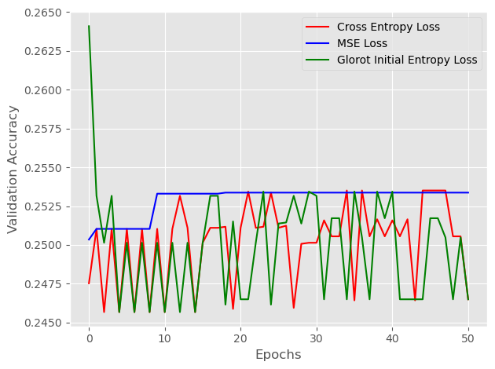

```python
print_result(nn_cross,X_train,y_train,X_test,y_test,title="Cross Entropy Loss",color="red")
print_result(nn_quad,X_train,y_train,X_test,y_test,title="MSE Loss",color="blue")
print_result(nn_glorot,X_train,y_train,X_test,y_test,title="Glorot Initial Entropy Loss",color="green")


plt.show()
```

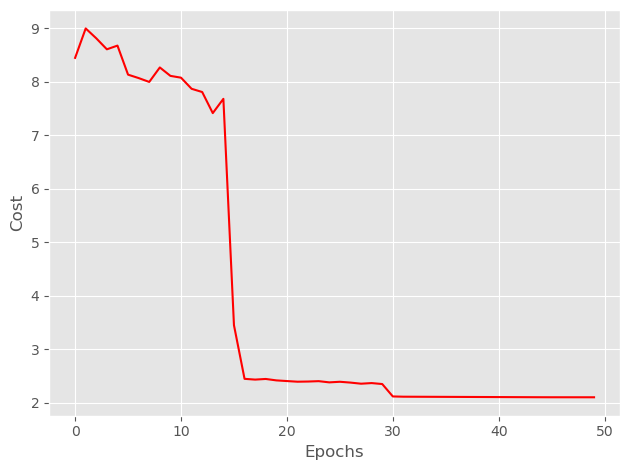

```python
# take the mean of each minibatch epoch
cost_avgs = [np.mean(x) for x in nn_glorot.cost_]

plt.plot(range(len(cost_avgs)), cost_avgs, color='red')
plt.ylabel('Cost')
plt.xlabel('Epochs')
plt.tight_layout()
plt.show()
```

### Using Normalization

```python
scaler = StandardScaler()
X_train = scaler.fit_transform(X_train)
X_test = scaler.transform(X_test)
```

```python
vals = { 'n_hidden':30,
         'C':0.01, 'epochs':50, 'eta':0.01,
         'alpha':0.001, 'decrease_const':0.1, 'decrease_iter':15,
         'minibatches':50,
         'shuffle':True,'random_state':1}

nn_quad = TLPMiniBatch(**vals)
nn_cross = TLPMiniBatchCrossEntropy(**vals)
nn_glorot = TLPBetterInitial(**vals)


%time nn_cross.fit(X_train, y_train, print_progress=1, XY_test=(X_test, y_test))
%time nn_quad.fit(X_train, y_train, print_progress=1, XY_test=(X_test, y_test))
%time nn_glorot.fit(X_train, y_train, print_progress=1, XY_test=(X_test, y_test))

print("Done")
```

[output not shown]

```
CPU times: user 1min 7s, sys: 8.56 s, total: 1min 15s
Wall time: 11.7 s
```

[output not shown]

```
CPU times: user 55.9 s, sys: 8.86 s, total: 1min 4s
Wall time: 9.62 s
```

```
Epoch: 50/50
```

```
CPU times: user 1min, sys: 8.91 s, total: 1min 9s
Wall time: 10.5 s
Done
```

```
=================
Cross Entropy Loss :
Resubstitution acc: 0.6850654931756455
Validation acc: 0.6818619361936193
=================
MSE Loss :
Resubstitution acc: 0.704868154158215
Validation acc: 0.7048267326732673
=================
Glorot Initialization Entropy Loss :
Resubstitution acc: 0.7306528689792691
Validation acc: 0.7274477447744775
```

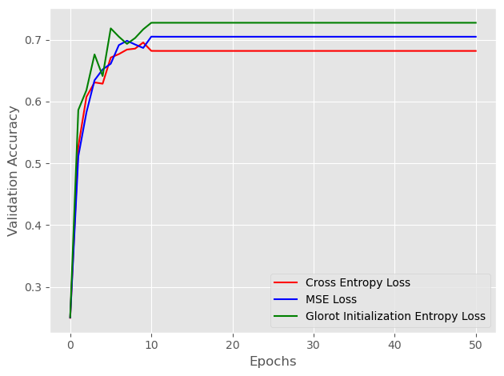

```python
print_result(nn_cross,X_train,y_train,X_test,y_test,title="Cross Entropy Loss",color="red")
print_result(nn_quad,X_train,y_train,X_test,y_test,title="MSE Loss",color="blue")
print_result(nn_glorot,X_train,y_train,X_test,y_test,title="Glorot Initialization Entropy Loss",color="green")

plt.show()
```

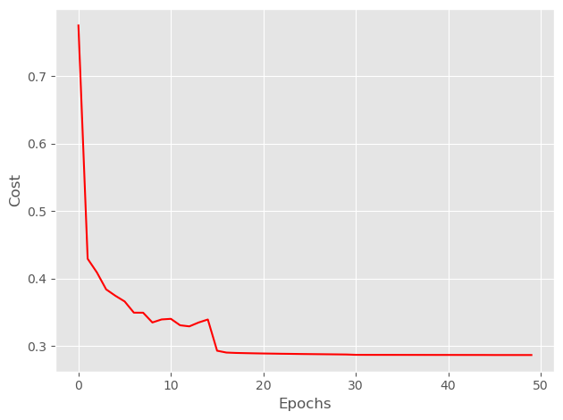

```python
# take the mean of each minibatch epoch
cost_avgs = [np.mean(x) for x in nn_glorot.cost_]

plt.plot(range(len(cost_avgs)), cost_avgs, color='red')
plt.ylabel('Cost')
plt.xlabel('Epochs')
plt.tight_layout()
plt.show()
```

### Using One hot encoding and Normalization

```python
import pandas as pd
from sklearn.preprocessing import StandardScaler
from sklearn.model_selection import train_test_split
from sklearn.linear_model import LinearRegression  # You can use other models depending on your problem
from sklearn.metrics import mean_squared_error

# Load your dataset
# data = pd.read_csv('acs2017_census_tract_data.csv')
data.dropna(inplace=True)

# Define the list of numerical columns to standardize
numerical_cols = [
    'TotalPop', 'Men', 'Women', 'Hispanic', 'White', 'Black', 'Native', 'Asian',
    'Pacific', 'VotingAgeCitizen', 'Income', 'IncomeErr', 'IncomePerCap',
    'IncomePerCapErr', 'Poverty', 'Professional', 'Service', 'Office',
    'Construction', 'Production', 'Drive', 'Carpool', 'Transit', 'Walk',
    'OtherTransp', 'WorkAtHome', 'MeanCommute', 'Employed', 'PrivateWork',
    'PublicWork', 'SelfEmployed', 'FamilyWork', 'Unemployment'
]

# One-hot encode categorical columns (State and County)
categorical_cols = ['State', 'County']
data_encoded = pd.get_dummies(data, columns=categorical_cols)

scaler = StandardScaler()
data_encoded[numerical_cols] = scaler.fit_transform(data_encoded[numerical_cols])
data_encoded.drop('TractId',axis=1,inplace=True)

# # Separate the target variable (ChildPoverty)

X, y = data_encoded.drop("ChildPoverty",axis=1).values , data_encoded["ChildPoverty"].values



# Split the data into training and testing sets
X_train, X_test, y_train, y_test = train_test_split(X, y, test_size=0.2)
y_train, y_test = quantize_poverty(y_train, y_test)

# Print the updated y_train and y_test
print("Updated y_train:")
print(y_train)
print("Updated y_test:")
print(y_test)
```

```
Threshold Points: [6.200000000000405, 16.30099999999694, 31.600000000015637]
Quantized y_train:
[3. 2. 0. ... 1. 1. 2.]
Quantized y_test:
[2. 0. 1. ... 2. 1. 2.]
Updated y_train:
[3. 2. 0. ... 1. 1. 2.]
Updated y_test:
[2. 0. 1. ... 2. 1. 2.]
```

```python
vals = { 'n_hidden':30,
         'C':0.01, 'epochs':50, 'eta':0.01,
         'alpha':0.001, 'decrease_const':0.1, 'decrease_iter':15,
         'minibatches':50,
         'shuffle':True,'random_state':1}

nn_quad = TLPMiniBatch(**vals)
nn_cross = TLPMiniBatchCrossEntropy(**vals)
nn_glorot = TLPBetterInitial(**vals)


%time nn_cross.fit(X_train, y_train, print_progress=1, XY_test=(X_test, y_test))
%time nn_quad.fit(X_train, y_train, print_progress=1, XY_test=(X_test, y_test))
%time nn_glorot.fit(X_train, y_train, print_progress=1, XY_test=(X_test, y_test))

print("Done")
```

```
Epoch: 50/50
```

```
CPU times: user 6min 54s, sys: 1min 13s, total: 8min 8s
Wall time: 1min 22s
```

```
Epoch: 50/50
```

```
CPU times: user 7min 59s, sys: 1min 24s, total: 9min 24s
Wall time: 1min 39s
```

```
Epoch: 50/50
```

```
CPU times: user 9min 28s, sys: 1min 29s, total: 10min 57s
Wall time: 1min 53s
Done
```

[output not shown]

[figure not shown]

```python
print_result(nn_cross,X_train,y_train,X_test,y_test,title="Cross Entropy Loss",color="red")
print_result(nn_quad,X_train,y_train,X_test,y_test,title="MSE Loss",color="blue")
print_result(nn_glorot,X_train,y_train,X_test,y_test,title="Glorot Initialization Entropy Loss",color="green")


plt.show()
```

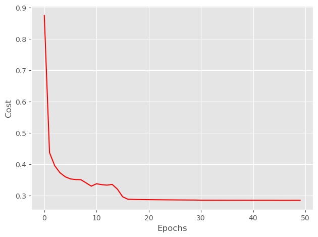

```python
# take the mean of each minibatch epoch
cost_avgs = [np.mean(x) for x in nn_glorot.cost_]

plt.plot(range(len(cost_avgs)), cost_avgs, color='red')
plt.ylabel('Cost')
plt.xlabel('Epochs')
plt.tight_layout()
plt.show()
```

Comparing the results by all the 3 techniques:

We would be comparing Glorot Intialized values for comparing the 3 ways we approached this problem:

Model without Preprocessing (Raw Data):

Accuracy: 25% Training Time: Around 1 minute The model's accuracy is relatively low, indicating that it struggles to make accurate predictions on the test data. Without preprocessing, the model might be affected by varying feature scales and categorical data, leading to convergence issues.

Model with Normalization:

Accuracy: 73% Training Time: Approximately 1 minute. The model's accuracy has improved compared to the unprocessed data. Normalization standardizes the feature values, ensuring that they have similar scales, which helps the model converge more effectively.

Model with Normalization and One-Hot Encoding:

Explanation:

The differences in performance among these models can be attributed to the data preprocessing steps applied:

The model without preprocessing performed the worst. Without normalization or one-hot encoding, it struggled to make accurate predictions, likely due to issues related to varying feature scales and categorical data.

The model with normalization improved accuracy. Normalization addresses the issue of varying feature scales, making it easier for the model to converge.

### 3 LAYER PERCEPTRON

```python
import numpy as np
from scipy.special import expit
import pandas as pd

class ThreeLayerPerceptronBase(object):
    def __init__(self, n_hidden1=30, n_hidden2=30,
                 C=0.0, epochs=500, eta=0.001, random_state=None):
        np.random.seed(random_state)
        self.n_hidden1 = n_hidden1
        self.n_hidden2 = n_hidden2
        self.l2_C = C
        self.epochs = epochs
        self.eta = eta
        self.average_gradients = {'W1': [], 'W2': [], 'W3': []}


    @staticmethod
    def _encode_labels(y):
        """Encode labels into one-hot representation"""
        onehot = pd.get_dummies(y).values.T
        return onehot

    def _initialize_weights(self):
        W1_num_elems = (self.n_features_)*self.n_hidden1
        W1 = np.random.uniform(-1.0, 1.0, size=W1_num_elems)
        W1 = W1.reshape(self.n_hidden1, self.n_features_)
        b1 = np.zeros((self.n_hidden1, 1))

        W2_num_elems = (self.n_hidden1) * self.n_hidden2
        W2 = np.random.uniform(-1.0, 1.0, size=W2_num_elems)
        W2 = W2.reshape(self.n_hidden2, self.n_hidden1)
        b2 = np.zeros((self.n_hidden2, 1))

        W3_num_elems = (self.n_hidden2) * self.n_output_
        W3 = np.random.uniform(-1.0, 1.0, size=W3_num_elems)
        W3 = W3.reshape(self.n_output_, self.n_hidden2)
        b3 = np.zeros((self.n_output_, 1))

        return W1, W2, W3, b1, b2, b3

    @staticmethod
    def _sigmoid(z):
        """Use scipy.special.expit to avoid overflow"""
        # 1.0 / (1.0 + np.exp(-z))
        return expit(z)

    @staticmethod
    def _L2_reg(lambda_, W1, W2, W3):
        """Compute L2-regularization cost"""
        # only compute for non-bias terms
        return (lambda_/2.0) * np.sqrt(np.mean(W1[:, 1:] ** 2) + np.mean(W2[:, 1:] ** 2) + np.mean(W3[:, 1:] ** 2))

    def _cost(self, A4, Y_enc, W1, W2, W3):
        '''Get the objective function value'''
        cost = np.mean((Y_enc - A4) ** 2)
        L2_term = self._L2_reg(self.l2_C, W1, W2, W3)
        return cost + L2_term


    def _feedforward(self, X, W1, W2, W3, b1, b2, b3):
        A1 = X.T
        Z1 = W1 @ A1 + b1
        A2 = self._sigmoid(Z1)
        Z2 = W2 @ A2 + b2
        A3 = self._sigmoid(Z2)
        Z3 = W3 @ A3 + b3
        A4 = self._sigmoid(Z3)
        return A1, Z1, A2, Z2, A3, Z3, A4

    def _get_gradient(self, A1, A2, A3, A4, Z1, Z2, Z3, Y_enc, W1, W2, W3):
        V3 = -2*(Y_enc-A4)*A4*(1-A4)
        V2 = A3*(1-A3)*(W3.T @ V3)
        V1 = A2*(1-A2)*(W2.T @ V2)

        gradW3 = V3 @ A3.T
        gradW2 = V2 @ A2.T
        gradW1 = V1 @ A1.T

        gradb3 = np.sum(V3, axis=1).reshape((-1, 1))
        gradb2 = np.sum(V2, axis=1).reshape((-1, 1))
        gradb1 = np.sum(V1, axis=1).reshape((-1, 1))

        gradW3 += W3 * self.l2_C
        gradW2 += W2 * self.l2_C
        gradW1 += W1 * self.l2_C


        return gradW1, gradW2, gradW3, gradb1, gradb2, gradb3

    def predict(self, X):
        _, _, _, _, _, _, A4 = self._feedforward(X, self.W1, self.W2, self.W3, self.b1, self.b2, self.b3)
        y_pred = np.argmax(A4, axis=0)
        return y_pred

    def plot_average_gradients(self):
        import matplotlib.pyplot as plt
        for layer, magnitudes in self.average_gradients.items():
            plt.plot(magnitudes, label=f'Layer {layer}')

        plt.xlabel('Epochs')
        plt.ylabel('Average Gradient Magnitude')
        plt.legend()
        plt.show()
```

```python
class ThreeLayerTLPMiniBatch(ThreeLayerPerceptronBase):  # Changed the class to use the ThreeLayerPerceptronBase

    def __init__(self, alpha=0.0, decrease_const=0.1,
                 decrease_iter=10, shuffle=True,
                 minibatches=1, **kwds):
        # need to add to the original initializer
        self.alpha = alpha
        self.decrease_const = decrease_const
        self.decrease_iter = decrease_iter
        self.shuffle = shuffle
        self.minibatches = minibatches
        # but keep other keywords
        super().__init__(**kwds)

    def fit(self, X, y, print_progress=False, XY_test=None):
        """ Learn weights from training data. With mini-batch"""
        X_data, y_data = X.copy(), y.copy()
        Y_enc = self._encode_labels(y)

        # init weights and setup matrices
        self.n_features_ = X_data.shape[1]
        self.n_output_ = Y_enc.shape[0]
        self.W1, self.W2, self.W3, self.b1, self.b2, self.b3 = self._initialize_weights()

        # start momentum at zero for previous updates
        rho_W1_prev = np.zeros(self.W1.shape)  # for momentum
        rho_W2_prev = np.zeros(self.W2.shape)  # for momentum
        rho_W3_prev = np.zeros(self.W3.shape)  # for momentum

        self.cost_ = []
        self.score_ = []
        # get starting acc
        self.score_.append(accuracy_score(y_data, self.predict(X_data)))
        # keep track of validation, if given
        if XY_test is not None:
            X_test = XY_test[0].copy()
            y_test = XY_test[1].copy()
            self.val_score_ = []
            self.val_score_.append(accuracy_score(y_test, self.predict(X_test)))
            self.val_cost_ = []

        for i in range(self.epochs):
            # adaptive learning rate
            # decrease at certain epochs
            eta = self.eta * self.decrease_const**(np.floor(i / self.decrease_iter))

            if print_progress > 0 and (i + 1) % print_progress == 0:
                sys.stderr.write('\rEpoch: %d/%d' % (i + 1, self.epochs))
                sys.stderr.flush()

            if self.shuffle:
                idx_shuffle = np.random.permutation(y_data.shape[0])
                X_data, Y_enc, y_data = X_data[idx_shuffle], Y_enc[:, idx_shuffle], y_data[idx_shuffle]

            mini = np.array_split(range(y_data.shape[0]), self.minibatches)
            mini_cost = []
            for idx in mini:
                # feedforward
                A1, Z1, A2, Z2, A3, Z3, A4 = self._feedforward(X_data[idx],
                                                               self.W1, self.W2, self.W3,
                                                               self.b1, self.b2, self.b3)

                cost = self._cost(A4, Y_enc[:, idx], self.W1, self.W2, self.W3)
                mini_cost.append(cost)  # this appends cost of mini-batch only

                # compute gradient via backpropagation
                gradW1, gradW2, gradW3, gradb1, gradb2, gradb3 = self._get_gradient(A1=A1, A2=A2, A3=A3,A4=A4 , Z1=Z1, Z2=Z2, Z3=Z3,
                                                  Y_enc=Y_enc[:, idx],
                                                  W1=self.W1,W2=self.W2,W3=self.W3)

                # simple momentum calculations

                rho_W1, rho_W2, rho_W3 = eta * gradW1, eta * gradW2, eta * gradW3
                self.W1 -= (rho_W1 + (self.alpha * rho_W1_prev)) # update with momentum
                self.W2 -= (rho_W2 + (self.alpha * rho_W2_prev)) # update with momentum
                self.W3 -= (rho_W3 + (self.alpha * rho_W3_prev))

                # no need for momentum in bias
                # these values need to change abruptly and
                # do not influence sensitivity backward
                self.b1 -= eta * gradb1
                self.b2 -= eta * gradb2
                self.b3 -= eta * gradb3

                # update previous parameters
                rho_W1_prev, rho_W2_prev, rho_W3_prev = rho_W1, rho_W2, rho_W3



            self.cost_.append(np.mean(mini_cost))
            self.score_.append(accuracy_score(y_data,self.predict(X_data)))

            # update if a validation set was provided
            if XY_test is not None:
                yhat = self.predict(X_test)
                self.val_score_.append(accuracy_score(y_test,yhat))

        return self
```

```python
class ThreeLayerTLPMiniBatchCrossEntropy(ThreeLayerTLPMiniBatch):

    # Override the cost function
    def _cost(self, A4, Y_enc, W1, W2, W3):
        '''Get the objective function value'''
        cost = -np.mean(np.nan_to_num((Y_enc * np.log(A4 + 1e-7) + (1 - Y_enc) * np.log(1 - A4 + 1e-7))))
        L2_term = self._L2_reg(self.l2_C, W1, W2, W3)
        return cost + L2_term

    # Override the gradient calculation
    def _get_gradient(self, A1, A2, A3, A4, Z1, Z2, Z3, Y_enc, W1, W2, W3):
        """ Compute gradient step using backpropagation.
        """
        # vectorized backpropagation
        V3 = (A4-Y_enc)
        V2 = A3*(1-A3)*(W3.T @ V3)
        V1 = A2*(1-A2)*(W2.T @ V2)

        gradW3 = V3 @ A3.T
        gradW2 = V2 @ A2.T
        gradW1 = V1 @ A1.T

        gradb3 = np.sum(V3, axis=1).reshape((-1, 1))
        gradb2 = np.sum(V2, axis=1).reshape((-1, 1))
        gradb1 = np.sum(V1, axis=1).reshape((-1, 1))

        # Regularize weights that are not bias terms
        gradW1 += W1 * self.l2_C
        gradW2 += W2 * self.l2_C
        gradW3 += W3 * self.l2_C

        avg_gradW1 = np.mean(np.abs(gradW1))
        avg_gradW2 = np.mean(np.abs(gradW2))
        avg_gradW3 = np.mean(np.abs(gradW3))


        self.average_gradients['W1'].append(avg_gradW1)
        self.average_gradients['W2'].append(avg_gradW2)
        self.average_gradients['W3'].append(avg_gradW3)

        return gradW1, gradW2, gradW3, gradb1, gradb2, gradb3
```

```python
#Glorot Initialization
class ThreeLayerTLPBetterInitial(ThreeLayerTLPMiniBatchCrossEntropy):

    def _initialize_weights(self):
        """Initialize weights Glorot and He normalization."""
        init_bound = 4 * np.sqrt(6. / (self.n_hidden1 + self.n_features_))
        W1 = np.random.uniform(-init_bound, init_bound, (self.n_hidden1, self.n_features_))

        init_bound = 4 * np.sqrt(6. / (self.n_hidden2 + self.n_hidden1))
        W2 = np.random.uniform(-init_bound, init_bound, (self.n_hidden2, self.n_hidden1))

        init_bound = 4 * np.sqrt(6. / (self.n_output_ + self.n_hidden2))
        W3 = np.random.uniform(-init_bound, init_bound, (self.n_output_, self.n_hidden2))

        # Set biases to zero to avoid immediate saturation
        b1 = np.zeros((self.n_hidden1, 1))
        b2 = np.zeros((self.n_hidden2, 1))
        b3 = np.zeros((self.n_output_, 1))

        return W1, W2, W3, b1, b2, b3
```

```python
vals = { 'n_hidden1':30, 'n_hidden2':30,
         'C':0.1, 'epochs':50, 'eta':0.01, # poor starting learning rate!!
         'alpha':0.001, 'decrease_const':0.1, 'decrease_iter':15,
         'minibatches':50,
         'shuffle':True,'random_state':1}

nn_quad = ThreeLayerTLPMiniBatch(**vals)
nn_cross = ThreeLayerTLPMiniBatchCrossEntropy(**vals)
nn_glorot  = ThreeLayerTLPBetterInitial(**vals)

%time nn_cross.fit(X_train, y_train, print_progress=1, XY_test=(X_test, y_test))
%time nn_quad.fit(X_train, y_train, print_progress=1, XY_test=(X_test, y_test))
%time nn_glorot.fit(X_train, y_train, print_progress=1, XY_test=(X_test, y_test))

print("Done")
```

```
Epoch: 50/50
```

```
CPU times: user 7min 55s, sys: 1min 40s, total: 9min 36s
Wall time: 1min 34s
```

```
Epoch: 50/50
```

```
CPU times: user 7min 25s, sys: 1min 39s, total: 9min 4s
Wall time: 1min 27s
```

```
Epoch: 50/50
```

```
CPU times: user 7min 12s, sys: 1min 40s, total: 8min 52s
Wall time: 1min 24s
Done
```

```
=================
Cross Entropy Loss :
Resubstitution acc: 0.7393509127789046
Validation acc: 0.733567106710671
=================
MSE Loss :
Resubstitution acc: 0.7374084642623853
Validation acc: 0.7312293729372937
=================
Glorot Intitialization Cross Entropy Loss :
Resubstitution acc: 0.7402275930828205
Validation acc: 0.7255913091309131
```

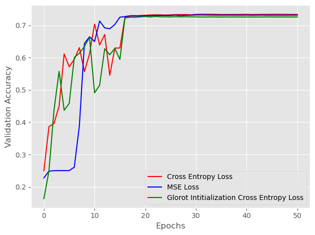

```python
print_result(nn_cross,X_train,y_train,X_test,y_test,title="Cross Entropy Loss",color="red")
print_result(nn_quad,X_train,y_train,X_test,y_test,title="MSE Loss",color="blue")
print_result(nn_glorot,X_train,y_train,X_test,y_test,title="Glorot Intitialization Cross Entropy Loss",color="green")


plt.show()
```

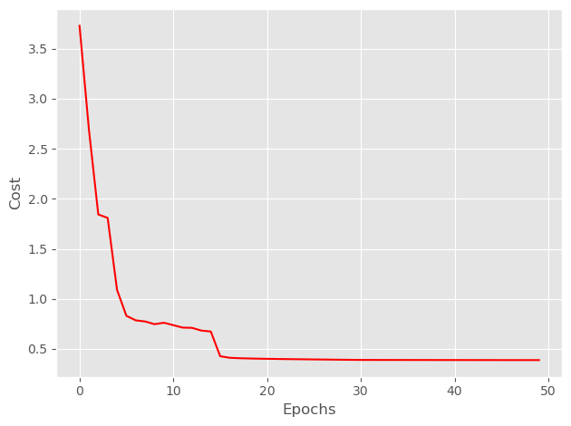

```python
# take the mean of each minibatch epoch
cost_avgs = [np.mean(x) for x in nn_glorot.cost_]

plt.plot(range(len(cost_avgs)), cost_avgs, color='red')
plt.ylabel('Cost')
plt.xlabel('Epochs')
plt.tight_layout()
plt.show()
```

### 4 LAYER PERCEPTRON

```python
import numpy as np
from scipy.special import expit
import pandas as pd

class FourLayerPerceptronBase(object):
    def __init__(self, n_hidden1=30, n_hidden2=30, n_hidden3 = 30,
                 C=0.0, epochs=500, eta=0.001, random_state=None):
        np.random.seed(random_state)
        self.n_hidden1 = n_hidden1
        self.n_hidden2 = n_hidden2
        self.n_hidden3 = n_hidden3
        self.l2_C = C
        self.epochs = epochs
        self.eta = eta

    @staticmethod
    def _encode_labels(y):
        """Encode labels into one-hot representation"""
        onehot = pd.get_dummies(y).values.T
        return onehot

    def _initialize_weights(self):
        W1_num_elems = (self.n_features_)*self.n_hidden1
        W1 = np.random.uniform(-1.0, 1.0, size=W1_num_elems)
        W1 = W1.reshape(self.n_hidden1, self.n_features_)
        b1 = np.zeros((self.n_hidden1, 1))

        W2_num_elems = (self.n_hidden1) * self.n_hidden2
        W2 = np.random.uniform(-1.0, 1.0, size=W2_num_elems)
        W2 = W2.reshape(self.n_hidden2, self.n_hidden1)
        b2 = np.zeros((self.n_hidden2, 1))

        W3_num_elems = (self.n_hidden2) * self.n_hidden3
        W3 = np.random.uniform(-1.0, 1.0, size=W3_num_elems)
        W3 = W3.reshape(self.n_hidden3, self.n_hidden2)
        b3 = np.zeros((self.n_hidden3, 1))

        W4_num_elems = (self.n_hidden3) * self.n_output_
        W4 = np.random.uniform(-1.0, 1.0, size=W4_num_elems)
        W4 = W4.reshape(self.n_output_, self.n_hidden3)
        b4 = np.zeros((self.n_output_, 1))

        return W1, W2, W3, W4, b1, b2, b3, b4

    @staticmethod
    def _sigmoid(z):
        """Use scipy.special.expit to avoid overflow"""
        # 1.0 / (1.0 + np.exp(-z))
        return expit(z)

    @staticmethod
    def _L2_reg(lambda_, W1, W2, W3, W4):
        """Compute L2-regularization cost"""
        # only compute for non-bias terms
        return (lambda_/2.0) * np.sqrt(np.mean(W1[:, 1:] ** 2) + np.mean(W2[:, 1:] ** 2) + np.mean(W3[:, 1:] ** 2) + np.mean(W4[:, 1:] ** 2))

    def _cost(self, A5, Y_enc, W1, W2, W3, W4):
        '''Get the objective function value'''
        cost = np.mean((Y_enc - A5) ** 2)
        L2_term = self._L2_reg(self.l2_C, W1, W2, W3, W4)
        return cost + L2_term


    def _feedforward(self, X, W1, W2, W3, W4, b1, b2, b3, b4):
        A1 = X.T
        Z1 = W1 @ A1 + b1
        A2 = self._sigmoid(Z1)
        Z2 = W2 @ A2 + b2
        A3 = self._sigmoid(Z2)
        Z3 = W3 @ A3 + b3
        A4 = self._sigmoid(Z3)
        Z4 = W4 @ A4 + b4
        A5 = self._sigmoid(Z4)
        return A1, Z1, A2, Z2, A3, Z3, A4, Z4, A5

    def _get_gradient(self, A1, A2, A3, A4, A5, Z1, Z2, Z3, Z4, Y_enc, W1, W2, W3, W4):
        """ Compute gradient step using backpropagation.
        """
        V5 = (A5 - Y_enc)
        V4 = A4 * (1 - A4) * (W4.T @ V5)
        V3 = A3 * (1 - A3) * (W3.T @ V4)
        V2 = A2 * (1 - A2) * (W2.T @ V3)
        V1 = A1 * (1 - A1) * (W1.T @ V2)

        gradW4 = V5 @ A4.T
        gradW3 = V4 @ A3.T
        gradW2 = V3 @ A2.T
        gradW1 = V2 @ A1.T

        gradb4 = np.sum(V5, axis=1).reshape((-1, 1))
        gradb3 = np.sum(V4, axis=1).reshape((-1, 1))
        gradb2 = np.sum(V3, axis=1).reshape((-1, 1))
        gradb1 = np.sum(V2, axis=1).reshape((-1, 1))

        # Regularize weights that are not bias terms
        gradW4 += W4 * self.l2_C
        gradW3 += W3 * self.l2_C
        gradW2 += W2 * self.l2_C
        gradW1 += W1 * self.l2_C

        return gradW1, gradW2, gradW3, gradW4, gradb1, gradb2, gradb3, gradb4

    def predict(self, X):
        _, _, _, _, _, _, _, _, A5 = self._feedforward(X, self.W1, self.W2, self.W3, self.W4, self.b1, self.b2, self.b3, self.b4)
        y_pred = np.argmax(A5, axis=0)
        return y_pred
```

```python
class TLPMiniBatchFourLayer(FourLayerPerceptronBase):
    def __init__(self, alpha=0.0, decrease_const=0.1,
                 decrease_iter=10, shuffle=True,
                 minibatches=1, **kwds):
        self.alpha = alpha
        self.decrease_const = decrease_const
        self.decrease_iter = decrease_iter
        self.shuffle = shuffle
        self.minibatches = minibatches
        super().__init__(**kwds)

    def fit(self, X, y, print_progress=False, XY_test=None):
        X_data, y_data = X.copy(), y.copy()
        Y_enc = self._encode_labels(y)

        self.n_features_ = X_data.shape[1]
        self.n_output_ = Y_enc.shape[0]
        self.W1, self.W2, self.W3, self.W4, self.b1, self.b2, self.b3, self.b4 = self._initialize_weights()

        rho_W1_prev = np.zeros(self.W1.shape)
        rho_W2_prev = np.zeros(self.W2.shape)
        rho_W3_prev = np.zeros(self.W3.shape)
        rho_W4_prev = np.zeros(self.W4.shape)

        self.cost_ = []
        self.score_ = []
        self.score_.append(accuracy_score(y_data, self.predict(X_data)))

        if XY_test is not None:
            X_test = XY_test[0].copy()
            y_test = XY_test[1].copy()
            self.val_score_ = []
            self.val_score_.append(accuracy_score(y_test, self.predict(X_test)))
            self.val_cost_ = []

        for i in range(self.epochs):
            eta = self.eta * self.decrease_const**(np.floor(i / self.decrease_iter))

            if print_progress > 0 and (i + 1) % print_progress == 0:
                sys.stderr.write('\rEpoch: %d/%d' % (i + 1, self.epochs))
                sys.stderr.flush()

            if self.shuffle:
                idx_shuffle = np.random.permutation(y_data.shape[0])
                X_data, Y_enc, y_data = X_data[idx_shuffle], Y_enc[:, idx_shuffle], y_data[idx_shuffle]

            mini = np.array_split(range(y_data.shape[0]), self.minibatches)
            mini_cost = []
            for idx in mini:
                A1, Z1, A2, Z2, A3, Z3, A4, Z4, A5 = self._feedforward(X_data[idx],
                                                                     self.W1, self.W2, self.W3, self.W4,
                                                                     self.b1, self.b2, self.b3, self.b4)

                cost = self._cost(A5, Y_enc[:, idx], self.W1, self.W2, self.W3, self.W4)
                mini_cost.append(cost)

                gradW1, gradW2, gradW3, gradW4, gradb1, gradb2, gradb3, gradb4 = self._get_gradient(
                    A1=A1, A2=A2, A3=A3, A4=A4, A5=A5, Z1=Z1, Z2=Z2, Z3=Z3, Z4=Z4,
                    Y_enc=Y_enc[:, idx], W1=self.W1, W2=self.W2, W3=self.W3, W4=self.W4)

                rho_W1, rho_W2, rho_W3, rho_W4 = eta * gradW1, eta * gradW2, eta * gradW3, eta * gradW4
                self.W1 -= (rho_W1 + (self.alpha * rho_W1_prev))
                self.W2 -= (rho_W2 + (self.alpha * rho_W2_prev))
                self.W3 -= (rho_W3 + (self.alpha * rho_W3_prev))
                self.W4 -= (rho_W4 + (self.alpha * rho_W4_prev))

                self.b1 -= eta * gradb1
                self.b2 -= eta * gradb2
                self.b3 -= eta * gradb3
                self.b4 -= eta * gradb4

                rho_W1_prev, rho_W2_prev, rho_W3_prev, rho_W4_prev = rho_W1, rho_W2, rho_W3, rho_W4

            self.cost_.append(np.mean(mini_cost))
            self.score_.append(accuracy_score(y_data, self.predict(X_data)))

            if XY_test is not None:
                yhat = self.predict(X_test)
                self.val_score_.append(accuracy_score(y_test, yhat))

        return self


class TLPMiniBatchCrossEntropyFourLayer(TLPMiniBatchFourLayer):

    def _cost(self, A5, Y_enc, W1, W2, W3, W4):
        cost = -np.mean(np.nan_to_num((Y_enc * np.log(A5 + 1e-7) + (1 - Y_enc) * np.log(1 - A5 + 1e-7))))
        L2_term = self._L2_reg(self.l2_C, W1, W2, W3, W4)
        return cost + L2_term

    def _get_gradient(self, A1, A2, A3, A4, A5, Z1, Z2, Z3, Z4, Y_enc, W1, W2, W3, W4):
        V5 = (A5 - Y_enc)
        V4 = A4 * (1 - A4) * (W4.T @ V5)
        V3 = A3 * (1 - A3) * (W3.T @ V4)
        V2 = A2 * (1 - A2) * (W2.T @ V3)
        V1 = A1 * (1 - A1) * (W1.T @ V2)

        gradW4 = V5 @ A4.T
        gradW3 = V4 @ A3.T
        gradW2 = V3 @ A2.T
        gradW1 = V2 @ A1.T

        gradb4 = np.sum(V5, axis=1).reshape((-1, 1))
        gradb3 = np.sum(V4, axis=1).reshape((-1, 1))
        gradb2 = np.sum(V3, axis=1).reshape((-1, 1))
        gradb1 = np.sum(V2, axis=1).reshape((-1, 1))

        gradW4 += W4 * self.l2_C
        gradW3 += W3 * self.l2_C
        gradW2 += W2 * self.l2_C
        gradW1 += W1 * self.l2_C

        return gradW1, gradW2, gradW3, gradW4, gradb1, gradb2, gradb3, gradb4
```

```python
# Glorot Initialization
class TLPBetterInitialFourLayer(TLPMiniBatchCrossEntropyFourLayer):

    def _initialize_weights(self):
        """Initialize weights with Glorot and He normalization for a 4-layer network."""
        init_bound = 4 * np.sqrt(6. / (self.n_hidden1 + self.n_features_))
        W1 = np.random.uniform(-init_bound, init_bound, (self.n_hidden1, self.n_features_))

        init_bound = 4 * np.sqrt(6. / (self.n_hidden2 + self.n_hidden1))
        W2 = np.random.uniform(-init_bound, init_bound, (self.n_hidden2, self.n_hidden1))

        init_bound = 4 * np.sqrt(6. / (self.n_hidden3 + self.n_hidden2))
        W3 = np.random.uniform(-init_bound, init_bound, (self.n_hidden3, self.n_hidden2))

        init_bound = 4 * np.sqrt(6. / (self.n_output_ + self.n_hidden3))
        W4 = np.random.uniform(-init_bound, init_bound, (self.n_output_, self.n_hidden3))

        # Set biases to zero to avoid immediate saturation
        b1 = np.zeros((self.n_hidden1, 1))
        b2 = np.zeros((self.n_hidden2, 1))
        b3 = np.zeros((self.n_hidden3, 1))
        b4 = np.zeros((self.n_output_, 1))

        return W1, W2, W3, W4, b1, b2, b3, b4
```

```python
vals = {
    'n_hidden1': 30,
    'n_hidden2': 30,
    'n_hidden3': 10,  # Add the third hidden layer
    'C': 0.01,
    'epochs': 50,
    'eta': 0.001,
    'alpha': 0.001,
    'decrease_const': 0.0,
    'decrease_iter': 10,
    'minibatches': 50,
    'shuffle': True,
    'random_state': 1
}



nn_quad = TLPMiniBatchFourLayer(**vals)  # Create an instance of the 4-layer network
nn_cross = TLPMiniBatchCrossEntropyFourLayer(**vals)  # Create an instance of the 4-layer network with Cross Entropy
nn_glorot  = TLPBetterInitialFourLayer(**vals)
# Training the 4-layer neural networks
%time nn_cross.fit(X_train, y_train, print_progress=1, XY_test=(X_test, y_test))
%time nn_quad.fit(X_train, y_train, print_progress=1, XY_test=(X_test, y_test))
%time nn_glorot.fit(X_train, y_train, print_progress=1, XY_test=(X_test, y_test))

print("Done")
```

```
Epoch: 50/50
```

```
CPU times: user 12min 25s, sys: 3min 43s, total: 16min 9s
Wall time: 2min 31s
```

```
Epoch: 50/50
```

```
CPU times: user 12min 37s, sys: 3min 47s, total: 16min 25s
Wall time: 2min 34s
```

```
Epoch: 50/50
```

```
CPU times: user 12min 47s, sys: 3min 19s, total: 16min 7s
Wall time: 2min 25s
Done
```

```
=================
Cross Entropy Loss :
Resubstitution acc: 0.711520610582047
Validation acc: 0.7057205720572057
=================
MSE Loss :
Resubstitution acc: 0.7012067246536253
Validation acc: 0.7000825082508251
=================
Glorot Intitalization Cross Entropy :
Resubstitution acc: 0.7135146285282085
Validation acc: 0.7077145214521452
```

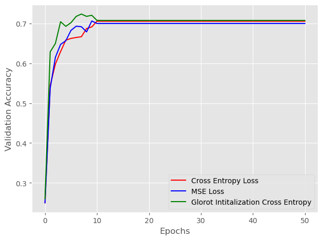

```python
print_result(nn_cross,X_train,y_train,X_test,y_test,title="Cross Entropy Loss",color="red")
print_result(nn_quad,X_train,y_train,X_test,y_test,title="MSE Loss",color="blue")
print_result(nn_glorot,X_train,y_train,X_test,y_test,title="Glorot Intitalization Cross Entropy",color="green")
```

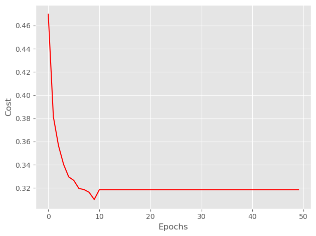

```python
# take the mean of each minibatch epoch
cost_avgs = [np.mean(x) for x in nn_glorot.cost_]

plt.plot(range(len(cost_avgs)), cost_avgs, color='red')
plt.ylabel('Cost')
plt.xlabel('Epochs')
plt.tight_layout()
plt.show()
```

### 5 LAYER PERCEPTRON

```python
class FiveLayerPerceptron(object):
    def __init__(self, n_hidden1=30, n_hidden2=30, n_hidden3=30, n_hidden4=30, C=0.0, epochs=500, eta=0.001, random_state=None):
        np.random.seed(random_state)
        self.n_hidden1 = n_hidden1
        self.n_hidden2 = n_hidden2
        self.n_hidden3 = n_hidden3
        self.n_hidden4 = n_hidden4
        self.l2_C = C
        self.epochs = epochs
        self.eta = eta


    # Rest of the class remains the same
    @staticmethod
    def _encode_labels(y):
        """Encode labels into one-hot representation"""
        onehot = pd.get_dummies(y).values.T
        return onehot

    def _initialize_weights(self):
        W1_num_elems = (self.n_features_) * self.n_hidden1
        W1 = np.random.uniform(-1.0, 1.0, size=W1_num_elems)
        W1 = W1.reshape(self.n_hidden1, self.n_features_)
        b1 = np.zeros((self.n_hidden1, 1))

        W2_num_elems = (self.n_hidden1) * self.n_hidden2
        W2 = np.random.uniform(-1.0, 1.0, size=W2_num_elems)
        W2 = W2.reshape(self.n_hidden2, self.n_hidden1)
        b2 = np.zeros((self.n_hidden2, 1))

        W3_num_elems = (self.n_hidden2) * self.n_hidden3
        W3 = np.random.uniform(-1.0, 1.0, size=W3_num_elems)
        W3 = W3.reshape(self.n_hidden3, self.n_hidden2)
        b3 = np.zeros((self.n_hidden3, 1))

        W4_num_elems = (self.n_hidden3) * self.n_hidden4
        W4 = np.random.uniform(-1.0, 1.0, size=W4_num_elems)
        W4 = W4.reshape(self.n_hidden4, self.n_hidden3)
        b4 = np.zeros((self.n_hidden4, 1))

        W5_num_elems = (self.n_hidden4) * self.n_output_
        W5 = np.random.uniform(-1.0, 1.0, size=W5_num_elems)
        W5 = W5.reshape(self.n_output_, self.n_hidden4)
        b5 = np.zeros((self.n_output_, 1))

        return W1, W2, W3, W4, W5, b1, b2, b3, b4, b5


    @staticmethod
    def _sigmoid(z):
        """Use scipy.special.expit to avoid overflow"""
        return expit(z)

    @staticmethod
    def _L2_reg(lambda_, W1, W2, W3, W4, W5):
        """Compute L2-regularization cost"""
        # Only compute for non-bias terms
        return (lambda_/2.0) * np.sqrt(np.mean(W1[:, 1:] ** 2) + np.mean(W2[:, 1:] ** 2) + np.mean(W3[:, 1:] ** 2) + np.mean(W4[:, 1:] ** 2) + np.mean(W5[:, 1:] ** 2))

    def _cost(self, A6, Y_enc, W1, W2, W3, W4, W5):
        '''Get the objective function value'''
        cost = np.mean((Y_enc - A6) ** 2)
        L2_term = self._L2_reg(self.l2_C, W1, W2, W3, W4, W5)
        return cost + L2_term


    def _feedforward(self, X, W1, W2, W3, W4, W5, b1, b2, b3, b4, b5):
        A1 = X.T
        Z1 = W1 @ A1 + b1
        A2 = self._sigmoid(Z1)
        Z2 = W2 @ A2 + b2
        A3 = self._sigmoid(Z2)
        Z3 = W3 @ A3 + b3
        A4 = self._sigmoid(Z3)
        Z4 = W4 @ A4 + b4
        A5 = self._sigmoid(Z4)
        Z5 = W5 @ A5 + b5
        A6 = self._sigmoid(Z5)
        return A1, Z1, A2, Z2, A3, Z3, A4, Z4, A5, Z5, A6

    def _get_gradient(self, A1, A2, A3, A4, A5, A6, Z1, Z2, Z3, Z4, Z5, Y_enc, W1, W2, W3, W4, W5):
        V6 = (A6 - Y_enc)
        V5 = A5 * (1 - A5) * (W5.T @ V6)
        V4 = A4 * (1 - A4) * (W4.T @ V5)
        V3 = A3 * (1 - A3) * (W3.T @ V4)
        V2 = A2 * (1 - A2) * (W2.T @ V3)
        V1 = A1 * (1 - A1) * (W1.T @ V2)

        gradW5 = V6 @ A5.T
        gradW4 = V5 @ A4.T
        gradW3 = V4 @ A3.T
        gradW2 = V3 @ A2.T
        gradW1 = V2 @ A1.T

        gradb5 = np.sum(V6, axis=1).reshape((-1, 1))
        gradb4 = np.sum(V5, axis=1).reshape((-1, 1))
        gradb3 = np.sum(V4, axis=1).reshape((-1, 1))
        gradb2 = np.sum(V3, axis=1).reshape((-1, 1))
        gradb1 = np.sum(V2, axis=1).reshape((-1, 1))

        gradW5 += W5 * self.l2_C
        gradW4 += W4 * self.l2_C
        gradW3 += W3 * self.l2_C
        gradW2 += W2 * self.l2_C
        gradW1 += W1 * self.l2_C

        return gradW1, gradW2, gradW3, gradW4, gradW5, gradb1, gradb2, gradb3, gradb4, gradb5

    def predict(self, X):
        _, _, _, _, _, _, _, _, _, _, A6 = self._feedforward(X, self.W1, self.W2, self.W3, self.W4, self.W5, self.b1, self.b2, self.b3, self.b4, self.b5)
        y_pred = np.argmax(A6, axis=0)
        return y_pred
```

```python
class TLPMiniBatchFiveLayer(FiveLayerPerceptron):
    def __init__(self, alpha=0.0, decrease_const=0.1, decrease_iter=10, shuffle=True, minibatches=1, **kwds):
        self.alpha = alpha
        self.decrease_const = decrease_const
        self.decrease_iter = decrease_iter
        self.shuffle = shuffle
        self.minibatches = minibatches
        super().__init__(**kwds)

    def fit(self, X, y, print_progress=False, XY_test=None):
        X_data, y_data = X.copy(), y.copy()
        Y_enc = self._encode_labels(y)

        self.n_features_ = X_data.shape[1]
        self.n_output_ = Y_enc.shape[0]
        self.W1, self.W2, self.W3, self.W4, self.W5, self.b1, self.b2, self.b3, self.b4, self.b5 = self._initialize_weights()

        rho_W1_prev = np.zeros(self.W1.shape)
        rho_W2_prev = np.zeros(self.W2.shape)
        rho_W3_prev = np.zeros(self.W3.shape)
        rho_W4_prev = np.zeros(self.W4.shape)
        rho_W5_prev = np.zeros(self.W5.shape)

        self.cost_ = []
        self.score_ = []
        self.score_.append(accuracy_score(y_data, self.predict(X_data)))

        if XY_test is not None:
            X_test = XY_test[0].copy()
            y_test = XY_test[1].copy()
            self.val_score_ = []
            self.val_score_.append(accuracy_score(y_test, self.predict(X_test)))
            self.val_cost_ = []

        for i in range(self.epochs):
            eta = self.eta * self.decrease_const**(np.floor(i / self.decrease_iter))

            if print_progress > 0 and (i + 1) % print_progress == 0:
                sys.stderr.write('\rEpoch: %d/%d' % (i + 1, self.epochs))
                sys.stderr.flush()

            if self.shuffle:
                idx_shuffle = np.random.permutation(y_data.shape[0])
                X_data, Y_enc, y_data = X_data[idx_shuffle], Y_enc[:, idx_shuffle], y_data[idx_shuffle]

            mini = np.array_split(range(y_data.shape[0]), self.minibatches)
            mini_cost = []
            for idx in mini:
                A1, Z1, A2, Z2, A3, Z3, A4, Z4, A5, Z5, A6 = self._feedforward(X_data[idx],
                                                                             self.W1, self.W2, self.W3, self.W4, self.W5,
                                                                             self.b1, self.b2, self.b3, self.b4, self.b5)

                cost = self._cost(A6, Y_enc[:, idx], self.W1, self.W2, self.W3, self.W4, self.W5)
                mini_cost.append(cost)

                gradW1, gradW2, gradW3, gradW4, gradW5, gradb1, gradb2, gradb3, gradb4, gradb5 = self._get_gradient(
                    A1=A1, A2=A2, A3=A3, A4=A4, A5=A5, A6=A6, Z1=Z1, Z2=Z2, Z3=Z3, Z4=Z4, Z5=Z5,
                    Y_enc=Y_enc[:, idx], W1=self.W1, W2=self.W2, W3=self.W3, W4=self.W4, W5=self.W5)

                rho_W1, rho_W2, rho_W3, rho_W4, rho_W5 = eta * gradW1, eta * gradW2, eta * gradW3, eta * gradW4, eta * gradW5
                self.W1 -= (rho_W1 + (self.alpha * rho_W1_prev))
                self.W2 -= (rho_W2 + (self.alpha * rho_W2_prev))
                self.W3 -= (rho_W3 + (self.alpha * rho_W3_prev))
                self.W4 -= (rho_W4 + (self.alpha * rho_W4_prev))
                self.W5 -= (rho_W5 + (self.alpha * rho_W5_prev))

                self.b1 -= eta * gradb1
                self.b2 -= eta * gradb2
                self.b3 -= eta * gradb3
                self.b4 -= eta * gradb4
                self.b5 -= eta * gradb5

                rho_W1_prev, rho_W2_prev, rho_W3_prev, rho_W4_prev, rho_W5_prev = rho_W1, rho_W2, rho_W3, rho_W4, rho_W5

            self.cost_.append(np.mean(mini_cost))
            self.score_.append(accuracy_score(y_data, self.predict(X_data)))

            if XY_test is not None:
                yhat = self.predict(X_test)
                self.val_score_.append(accuracy_score(y_test, yhat))

        return self


class TLPMiniBatchCrossEntropyFiveLayer(TLPMiniBatchFiveLayer):

    def _cost(self, A6, Y_enc, W1, W2, W3, W4, W5):
        cost = -np.mean(np.nan_to_num((Y_enc * np.log(A6 + 1e-7) + (1 - Y_enc) * np.log(1 - A6 + 1e-7))))
        L2_term = self._L2_reg(self.l2_C, W1, W2, W3, W4, W5)
        return cost + L2_term

    def _get_gradient(self, A1, A2, A3, A4, A5, A6, Z1, Z2, Z3, Z4, Z5, Y_enc, W1, W2, W3, W4, W5):
        V6 = (A6 - Y_enc)
        V5 = A5 * (1 - A5) * (W5.T @ V6)
        V4 = A4 * (1 - A4) * (W4.T @ V5)
        V3 = A3 * (1 - A3) * (W3.T @ V4)
        V2 = A2 * (1 - A2) * (W2.T @ V3)
        V1 = A1 * (1 - A1) * (W1.T @ V2)

        gradW5 = V6 @ A5.T
        gradW4 = V5 @ A4.T
        gradW3 = V4 @ A3.T
        gradW2 = V3 @ A2.T
        gradW1 = V2 @ A1.T

        gradb5 = np.sum(V6, axis=1).reshape((-1, 1))
        gradb4 = np.sum(V5, axis=1).reshape((-1, 1))
        gradb3 = np.sum(V4, axis=1).reshape((-1, 1))
        gradb2 = np.sum(V3, axis=1).reshape((-1, 1))
        gradb1 = np.sum(V2, axis=1).reshape((-1, 1))

        gradW5 += W5 * self.l2_C
        gradW4 += W4 * self.l2_C
        gradW3 += W3 * self.l2_C
        gradW2 += W2 * self.l2_C
        gradW1 += W1 * self.l2_C

        return gradW1, gradW2, gradW3, gradW4, gradW5, gradb1, gradb2, gradb3, gradb4, gradb5
```

```python
#Glorot Initialization

class TLPBetterInitialFiveLayer(TLPMiniBatchCrossEntropyFiveLayer):

    def _initialize_weights(self):
        """Initialize weights with Glorot and He normalization for a 5-layer network."""
        init_bound = 4 * np.sqrt(6. / (self.n_hidden1 + self.n_features_))
        W1 = np.random.uniform(-init_bound, init_bound, (self.n_hidden1, self.n_features_))

        init_bound = 4 * np.sqrt(6. / (self.n_hidden2 + self.n_hidden1))
        W2 = np.random.uniform(-init_bound, init_bound, (self.n_hidden2, self.n_hidden1))

        init_bound = 4 * np.sqrt(6. / (self.n_hidden3 + self.n_hidden2))
        W3 = np.random.uniform(-init_bound, init_bound, (self.n_hidden3, self.n_hidden2))

        init_bound = 4 * np.sqrt(6. / (self.n_hidden4 + self.n_hidden3))
        W4 = np.random.uniform(-init_bound, init_bound, (self.n_hidden4, self.n_hidden3))

        init_bound = 4 * np.sqrt(6. / (self.n_output_ + self.n_hidden4))
        W5 = np.random.uniform(-init_bound, init_bound, (self.n_output_, self.n_hidden4))

        # Set biases to zero to avoid immediate saturation
        b1 = np.zeros((self.n_hidden1, 1))
        b2 = np.zeros((self.n_hidden2, 1))
        b3 = np.zeros((self.n_hidden3, 1))
        b4 = np.zeros((self.n_hidden4, 1))
        b5 = np.zeros((self.n_output_, 1))

        return W1, W2, W3, W4, W5, b1, b2, b3, b4, b5
```

```python
vals = {
    'n_hidden1': 30,
    'n_hidden2': 30,
    'n_hidden3': 30,
    'n_hidden4': 10,  # Add the fourth hidden layer
    'C': 0.01,
    'epochs': 50,
    'eta': 0.001,
    'alpha': 0.001,
    'decrease_const': 0.0,
    'decrease_iter': 10,
    'minibatches': 50,
    'shuffle': True,
    'random_state': 1
}

nn_quad = TLPMiniBatchFiveLayer(**vals)  # Create an instance of the 5-layer network
nn_cross = TLPMiniBatchCrossEntropyFiveLayer(**vals)  # Create an instance of the 5-layer network with Cross Entropy
nn_glorot = TLPBetterInitialFiveLayer(**vals)  # Create an instance of the 5-layer network with Glorot and He initialization

# Training the 5-layer neural networks
%time nn_cross.fit(X_train, y_train, print_progress=1, XY_test=(X_test, y_test))
%time nn_quad.fit(X_train, y_train, print_progress=1, XY_test=(X_test, y_test))
%time nn_glorot.fit(X_train, y_train, print_progress=1, XY_test=(X_test, y_test))

print("Done")
```

```
Epoch: 50/50
```

```
CPU times: user 13min 15s, sys: 2min 56s, total: 16min 12s
Wall time: 2min 16s
```

```
Epoch: 50/50
```

```
CPU times: user 12min 13s, sys: 3min 4s, total: 15min 18s
Wall time: 2min 5s
```

```
Epoch: 50/50
```

```
CPU times: user 11min 58s, sys: 3min 2s, total: 15min
Wall time: 2min 4s
Done
```

[output not shown]

[figure not shown]

```python
print_result(nn_cross,X_train,y_train,X_test,y_test,title="Cross Entropy Loss",color="red")
print_result(nn_quad,X_train,y_train,X_test,y_test,title="MSE Loss",color="blue")
print_result(nn_glorot,X_train,y_train,X_test,y_test,title="Glorot Intitalization Cross Entropy",color="green")
```

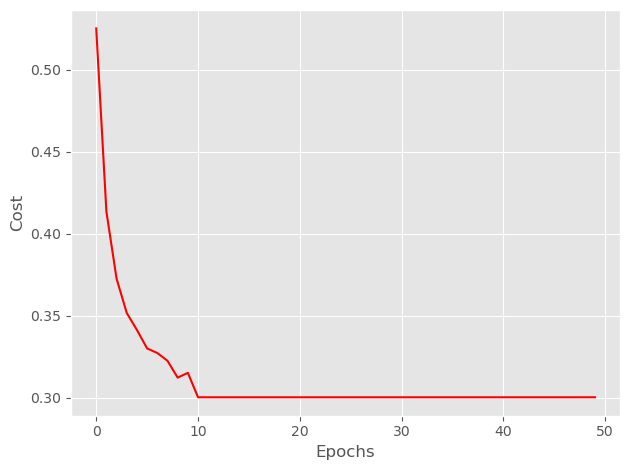

```python
cost_avgs = [np.mean(x) for x in nn_glorot.cost_]

plt.plot(range(len(cost_avgs)), cost_avgs, color='red')
plt.ylabel('Cost')
plt.xlabel('Epochs')
plt.tight_layout()
plt.show()
```

## Adding Adaptive Learning techniques

### Using AdaGrad

```python
class TLPAdaGradFiveLayer(TLPBetterInitialFiveLayer):

    def fit(self, X, y, print_progress=False, XY_test=None):
        """ Learn weights from training data. With mini-batch"""
        X_data, y_data = X.copy(), y.copy()
        Y_enc = self._encode_labels(y)

        # init weights and setup matrices
        self.n_features_ = X_data.shape[1]
        self.n_output_ = Y_enc.shape[0]
        self.W1, self.W2, self.W3, self.W4, self.W5, self.b1, self.b2, self.b3, self.b4, self.b5 = self._initialize_weights()

        # start momentum at zero for previous updates
        rho_W1_prev = np.zeros(self.W1.shape) # for momentum
        rho_W2_prev = np.zeros(self.W2.shape) # for momentum
        rho_W3_prev = np.zeros(self.W3.shape) # for momentum
        rho_W4_prev = np.zeros(self.W4.shape) # for momentum
        rho_W5_prev = np.zeros(self.W5.shape) # for momentum

        # adaptive G for entire gradient
        G1_prev = np.zeros(self.W1.shape) # for adaptive
        G2_prev = np.zeros(self.W2.shape) # for adaptive
        G3_prev = np.zeros(self.W3.shape) # for adaptive
        G4_prev = np.zeros(self.W4.shape) # for adaptive
        G5_prev = np.zeros(self.W5.shape) # for adaptive

        self.cost_ = []
        self.score_ = []

        # get starting accuracy
        self.score_.append(accuracy_score(y_data, self.predict(X_data)))

        # keep track of validation, if given
        if XY_test is not None:
            X_test = XY_test[0].copy()
            y_test = XY_test[1].copy()
            self.val_score_ = []
            self.val_score_.append(accuracy_score(y_test, self.predict(X_test)))
            self.val_cost_ = []

        for i in range(self.epochs):
            eta = self.eta * self.decrease_const**(np.floor(i / self.decrease_iter))

            if print_progress > 0 and (i + 1) % print_progress == 0:
                sys.stderr.write('\rEpoch: %d/%d' % (i + 1, self.epochs))
                sys.stderr.flush()

            if self.shuffle:
                idx_shuffle = np.random.permutation(y_data.shape[0])
                X_data, Y_enc, y_data = X_data[idx_shuffle], Y_enc[:, idx_shuffle], y_data[idx_shuffle]

            mini = np.array_split(range(y_data.shape[0]), self.minibatches)
            mini_cost = []
            for idx in mini:
                # feedforward
                A1, Z1, A2, Z2, A3, Z3, A4, Z4, A5, Z5, A6 = self._feedforward(X_data[idx],
                                                                     self.W1, self.W2, self.W3, self.W4, self.W5,
                                                                     self.b1, self.b2, self.b3, self.b4, self.b5)

                cost = self._cost(A6, Y_enc[:, idx], self.W1, self.W2, self.W3, self.W4, self.W5)
                mini_cost.append(cost)

                # compute gradient via backpropagation
                gradW1, gradW2, gradW3, gradW4, gradW5, gradb1, gradb2, gradb3, gradb4, gradb5 = self._get_gradient(
                    A1=A1, A2=A2, A3=A3, A4=A4, A5=A5, A6=A6, Z1=Z1, Z2=Z2, Z3=Z3, Z4=Z4, Z5=Z5,
                    Y_enc=Y_enc[:, idx], W1=self.W1, W2=self.W2, W3=self.W3, W4=self.W4, W5=self.W5)

                # momentum and adaptation calculations
                # Eta-grad implementation:
                G1 = gradW1 * gradW1 + self.alpha * G1_prev + 1e-7
                G2 = gradW2 * gradW2 + self.alpha * G2_prev + 1e-7
                G3 = gradW3 * gradW3 + self.alpha * G3_prev + 1e-7
                G4 = gradW4 * gradW4 + self.alpha * G4_prev + 1e-7
                G5 = gradW5 * gradW5 + self.alpha * G5_prev + 1e-7

                # momentum and adagrad
                rho_W1 = eta * gradW1 / np.sqrt(G1)
                rho_W2 = eta * gradW2 / np.sqrt(G2)
                rho_W3 = eta * gradW3 / np.sqrt(G3)
                rho_W4 = eta * gradW4 / np.sqrt(G4)
                rho_W5 = eta * gradW5 / np.sqrt(G5)

                self.W1 -= (rho_W1 + (self.alpha * rho_W1_prev)) # update with momentum
                self.W2 -= (rho_W2 + (self.alpha * rho_W2_prev)) # update with momentum
                self.W3 -= (rho_W3 + (self.alpha * rho_W3_prev)) # update with momentum
                self.W4 -= (rho_W4 + (self.alpha * rho_W4_prev)) # update with momentum
                self.W5 -= (rho_W5 + (self.alpha * rho_W5_prev)) # update with momentum
                self.b1 -= eta * gradb1
                self.b2 -= eta * gradb2
                self.b3 -= eta * gradb3
                self.b4 -= eta * gradb4
                self.b5 -= eta * gradb5

                # update previous parameters for the
                rho_W1_prev, rho_W2_prev = rho_W1, rho_W2
                rho_W3_prev, rho_W4_prev = rho_W3, rho_W4
                rho_W5_prev = rho_W5
                G1_prev, G2_prev = G1, G2
                G3_prev, G4_prev = G3, G4
                G5_prev = G5

            self.cost_.append(np.mean(mini_cost))
            self.score_.append(accuracy_score(y_data, self.predict(X_data)))

            if XY_test is not None:
                yhat = self.predict(X_test)
                self.val_score_.append(accuracy_score(y_test, yhat))

        return self
```

```
Epoch: 50/50
```

```
CPU times: user 14min 4s, sys: 2min 35s, total: 16min 40s
Wall time: 2min 16s
=================
Long Run :
Resubstitution acc: 0.7432701894317049
Validation acc: 0.738036303630363
```

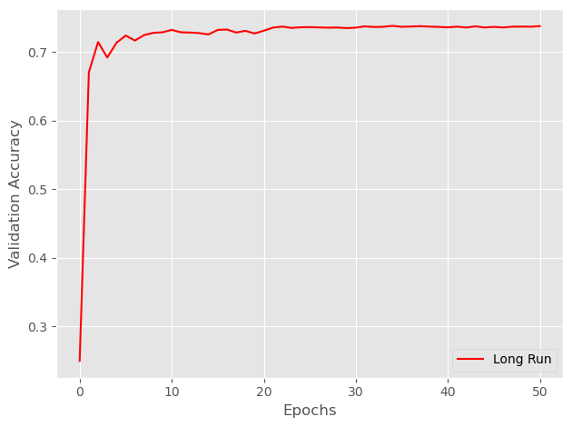

```python
# Adjust the hyperparameters as needed
vals = {
    'n_hidden1': 30,
    'n_hidden2': 30,
    'n_hidden3': 30,
    'n_hidden4': 10,  # Add the fourth hidden layer
    'C': 1e-2,
    'epochs': 50,
    'eta': 0.005,
    'alpha': 0.1,
    'decrease_const': 0.1,
    'decrease_iter': 20,
    'minibatches': len(X_train) / 256,
    'shuffle': True,
    'random_state': 1
}

# Create an instance of the 5-layer neural network
nn_long_ada = TLPAdaGradFiveLayer(**vals)

# Train the 5-layer neural network
%time nn_long_ada.fit(X_train, y_train, print_progress=1, XY_test=(X_test, y_test))
print_result(nn_long_ada, X_train, y_train, X_test, y_test, title="Long Run", color="red")
```

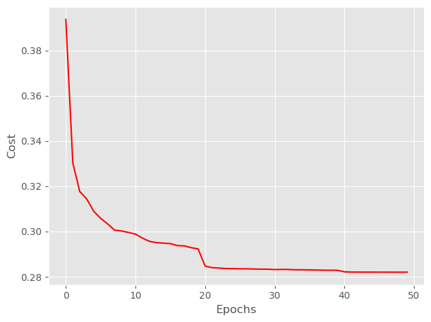

```python
cost_avgs = [np.mean(x) for x in nn_long_ada.cost_]

plt.plot(range(len(cost_avgs)), cost_avgs, color='red')
plt.ylabel('Cost')
plt.xlabel('Epochs')
plt.tight_layout()
plt.show()
```

## AdaDelta

```python
import numpy as np
import sys
from sklearn.metrics import accuracy_score

class TLPAdaDeltaFiveLayer(TLPBetterInitialFiveLayer):

    def fit(self, X, y, print_progress=False, XY_test=None):
        X_data, y_data = X.copy(), y.copy()
        Y_enc = self._encode_labels(y)

        self.n_features_ = X_data.shape[1]
        self.n_output_ = Y_enc.shape[0]
        self.W1, self.W2, self.W3, self.W4, self.W5, self.b1, self.b2, self.b3, self.b4, self.b5 = self._initialize_weights()

        # Parameters for AdaDelta
        epsilon = 1e-7
        rho = 0.95

        # Initialize accumulators
        E_gradW1_sq = np.zeros(self.W1.shape)
        E_gradW2_sq = np.zeros(self.W2.shape)
        E_gradW3_sq = np.zeros(self.W3.shape)
        E_gradW4_sq = np.zeros(self.W4.shape)
        E_gradW5_sq = np.zeros(self.W5.shape)
        E_delta_W1_sq = np.zeros(self.W1.shape)
        E_delta_W2_sq = np.zeros(self.W2.shape)
        E_delta_W3_sq = np.zeros(self.W3.shape)
        E_delta_W4_sq = np.zeros(self.W4.shape)
        E_delta_W5_sq = np.zeros(self.W5.shape)

        self.cost_ = []
        self.score_ = []
        self.score_.append(accuracy_score(y_data, self.predict(X_data)))

        if XY_test is not None:
            X_test = XY_test[0].copy()
            y_test = XY_test[1].copy()
            self.val_score_ = []
            self.val_score_.append(accuracy_score(y_test, self.predict(X_test)))
            self.val_cost_ = []

        for i in range(self.epochs):
            eta = self.eta * self.decrease_const**(np.floor(i / self.decrease_iter))

            if print_progress > 0 and (i + 1) % print_progress == 0:
                sys.stderr.write('\rEpoch: %d/%d' % (i + 1, self.epochs))
                sys.stderr.flush()

            if self.shuffle:
                idx_shuffle = np.random.permutation(y_data.shape[0])
                X_data, Y_enc, y_data = X_data[idx_shuffle], Y_enc[:, idx_shuffle], y_data[idx_shuffle]

            mini = np.array_split(range(y_data.shape[0]), self.minibatches)
            mini_cost = []

            for idx in mini:
                A1, Z1, A2, Z2, A3, Z3, A4, Z4, A5, Z5, A6 = self._feedforward(X_data[idx],
                                                                     self.W1, self.W2, self.W3, self.W4, self.W5,
                                                                     self.b1, self.b2, self.b3, self.b4, self.b5)

                cost = self._cost(A6, Y_enc[:, idx], self.W1, self.W2, self.W3, self.W4, self.W5)
                mini_cost.append(cost)

                gradW1, gradW2, gradW3, gradW4, gradW5, gradb1, gradb2, gradb3, gradb4, gradb5 = self._get_gradient(
                    A1=A1, A2=A2, A3=A3, A4=A4, A5=A5, A6=A6, Z1=Z1, Z2=Z2, Z3=Z3, Z4=Z4, Z5=Z5,
                    Y_enc=Y_enc[:, idx], W1=self.W1, W2=self.W2, W3=self.W3, W4=self.W4, W5=self.W5)

                # AdaDelta update
                E_gradW1_sq = rho * E_gradW1_sq + (1 - rho) * gradW1**2
                delta_W1 = np.sqrt((E_delta_W1_sq + epsilon) / (E_gradW1_sq + epsilon)) * gradW1
                self.W1 -= delta_W1

                E_gradW2_sq = rho * E_gradW2_sq + (1 - rho) * gradW2**2
                delta_W2 = np.sqrt((E_delta_W2_sq + epsilon) / (E_gradW2_sq + epsilon)) * gradW2
                self.W2 -= delta_W2

                E_gradW3_sq = rho * E_gradW3_sq + (1 - rho) * gradW3**2
                delta_W3 = np.sqrt((E_delta_W3_sq + epsilon) / (E_gradW3_sq + epsilon)) * gradW3
                self.W3 -= delta_W3

                E_gradW4_sq = rho * E_gradW4_sq + (1 - rho) * gradW4**2
                delta_W4 = np.sqrt((E_delta_W4_sq + epsilon) / (E_gradW4_sq + epsilon)) * gradW4
                self.W4 -= delta_W4

                E_gradW5_sq = rho * E_gradW5_sq + (1 - rho) * gradW5**2
                delta_W5 = np.sqrt((E_delta_W5_sq + epsilon) / (E_gradW5_sq + epsilon)) * gradW5
                self.W5 -= delta_W5

                # Update accumulators
                E_delta_W1_sq = rho * E_delta_W1_sq + (1 - rho) * delta_W1**2
                E_delta_W2_sq = rho * E_delta_W2_sq + (1 - rho) * delta_W2**2
                E_delta_W3_sq = rho * E_delta_W3_sq + (1 - rho) * delta_W3**2
                E_delta_W4_sq = rho * E_delta_W4_sq + (1 - rho) * delta_W4**2
                E_delta_W5_sq = rho * E_delta_W5_sq + (1 - rho) * delta_W5**2

                self.b1 -= eta * gradb1
                self.b2 -= eta * gradb2
                self.b3 -= eta * gradb3
                self.b4 -= eta * gradb4
                self.b5 -= eta * gradb5

            self.cost_.append(np.mean(mini_cost))
            self.score_.append(accuracy_score(y_data, self.predict(X_data)))

            if XY_test is not None:
                yhat = self.predict(X_test)
                self.val_score_.append(accuracy_score(y_test, yhat))

        return self
```

```
Epoch: 50/50
```

```
CPU times: user 12min 37s, sys: 2min 38s, total: 15min 15s
Wall time: 2min 1s
=================
Long Run (AdaDelta) :
Resubstitution acc: 0.7575549214425689
Validation acc: 0.7321232123212321
```

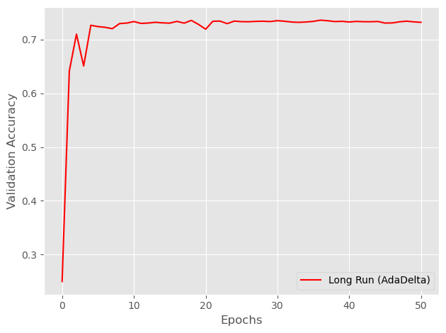

```python
# Adjust the hyperparameters as needed
vals = {
    'n_hidden1': 30,
    'n_hidden2': 30,
    'n_hidden3': 30,
    'n_hidden4': 10,  # Add the fourth hidden layer
    'C': 1e-2,
    'epochs': 50,
    'eta': 0.005,
    'alpha': 0.1,
    'decrease_const': 0.1,
    'decrease_iter': 20,
    'minibatches': len(X_train) // 256,  # Use integer division
    'shuffle': True,
    'random_state': 1
}

# Create an instance of the 5-layer neural network with AdaDelta optimizer
nn_long_adadelta = TLPAdaDeltaFiveLayer(**vals)

# Train the 5-layer neural network with AdaDelta optimizer
%time nn_long_adadelta.fit(X_train, y_train, print_progress=1, XY_test=(X_test, y_test))

# Print the results
print_result(nn_long_adadelta, X_train, y_train, X_test, y_test, title="Long Run (AdaDelta)", color="red")
```

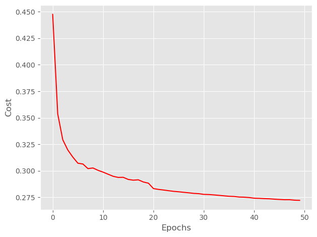

```python
cost_avgs = [np.mean(x) for x in nn_long_adadelta.cost_]

plt.plot(range(len(cost_avgs)), cost_avgs, color='red')
plt.ylabel('Cost')
plt.xlabel('Epochs')
plt.tight_layout()
plt.show()
```

We can see that when we use AdaDelta or Adagrad adapative learning method on top of the Glorot intialization (using cross entropy) help fine margins of increase in the performance of the model. However, we did observe that more or less similar accuracy across all methods.

In our model, adding AdaDelta and AdaGrad did not give any significant improvement to the accuracy scores. We got the results in a similar bucket.

### AdaM

```python
from sklearn.neural_network import MLPClassifier
clf = MLPClassifier(hidden_layer_sizes=(50, ),
                    activation='relu', # type of non-linearity, every layer except output layer
                    solver='adam',
                    alpha=1e-4, # L2 penalty
                    batch_size= 128, # min of 200, num_samples
                    learning_rate='adaptive', # adapt learning?
                    learning_rate_init=0.01, # only SGD
                    power_t=1,    # only SGD with inverse scaling of learning rate
                    max_iter=200, # stopping criteria
                    shuffle=True,
                    random_state=1,
                    tol=0, # for stopping
                    verbose=False,
                    momentum=0.9, # only SGD
                    nesterovs_momentum=False, # only SGD
                    early_stopping=False,
                    validation_fraction=0.0, # only if early_stop is true
                    beta_1=0.9, # adam decay rate of moment
                    beta_2=0.999, # adam decay rate of moment
                    epsilon=1e-08) # adam numerical stabilizer

%time clf.fit(X_train,y_train)
yhat = clf.predict(X_test)
print('Validation Acc:',accuracy_score(yhat,y_test))
```

```
CPU times: user 21min 37s, sys: 2min 5s, total: 23min 43s
Wall time: 3min 3s
Validation Acc: 0.6721672167216721
```

```python
from sklearn.metrics import confusion_matrix

# Assuming clf is your trained MLPClassifier
y_pred = clf.predict(X_test)  # Get the predictions on the test set

# Assuming y_test is the true labels for the test set
cm = confusion_matrix(y_test, y_pred)

# Print the confusion matrix
print("Confusion Matrix:")
print(cm)
```

```
Confusion Matrix:
[[2759  745  110   29]
 [ 867 2033  649   71]
 [ 104  863 2039  642]
 [  40   47  601 2945]]
```

Using AdaM on this dataset doesn't show any significant improvement to the accuracy. Also, the confusion matrix helps us identify the True and False classification of data points when AdaM was used on the dataset.

## References

[Kaggle]. US Census Dataset. Retrieved from https://www.kaggle.com/muonneutrino/us-census-demographic-data/data